# CENSUS 2021: Ethnicity, Identity, Language and Religion

The [CENSUS 2021](https://census.gov.uk) in England and Wales published data about [ethnic group, national identity, language, and religion](https://www.ons.gov.uk/releases/ethnicgroupnationalidentitylanguageandreligioncensus2021inenglandandwales). The release included four publications: [National identity](https://www.ons.gov.uk/peoplepopulationandcommunity/culturalidentity/ethnicity/bulletins/nationalidentityenglandandwales/census2021), [Religion](https://www.ons.gov.uk/peoplepopulationandcommunity/culturalidentity/religion/bulletins/religionenglandandwales/census2021), [Language](https://www.ons.gov.uk/peoplepopulationandcommunity/culturalidentity/language/bulletins/languageenglandandwales/census2021) and [Ethnic Group](https://www.ons.gov.uk/peoplepopulationandcommunity/culturalidentity/ethnicity/bulletins/ethnicgroupenglandandwales/census2021).

#### Ethnicity

In Trafford the percentage of white population has decreased by 7.7% from 85.5% in 2011 to 77.8% in 2021.

The most common non-white broad ethnic group is Asian/Asian British that has increased 4.7% from 7.9% in 2011 to 12.6% in 2021. All other non-white broad ethnic groups have also increased.

The percentage of households in Trafford where all household members have the same ethnic group has decreased 1.7% from 60.7% in 2011 to 59% in 2021. The percentage of households where ethnic groups differ within partnerships has increased 1.9% from 5.8% in 2011 to 7.7% in 2021. The percentage of households where ethnic groups differ between generations but not within partnerships has decreased 0.4% from 2.3% in 2011 to 1.9% 2021.

#### National identity

“British only” national identity was the most common response in 2021 with 62.1% whilst in 2011 the most common response was “English only”, this change could reflect a change in national identity but can also reflect a change to the question structure.

Residents with “Non-Uk only” identity increased 1.4% from 6.1% in 2011 to 7.5% in 2021. The most common non-UK identity in 2021 was “Irish” with 1.1% followed by “Polish” with 0.6%.

#### Languages

In 2021 92.8% of Trafford residents aged three and over declared English as their main language, a person’s first or preferred language, a 1.7% decrease from 2011. The top 5 non-English main languages in Trafford in 2021 were Urdu (0.9%), Polish (0.6%), Arabic (0.6%), Panjabi (0.4%) and Cantonese Chinese (0.4%). These differ from England and Wales top 5 non-english main languages in 2021 which were Polish (1.1%), Romanian (0.8%), Panjabi (0.5), Urdu (0.5), and Portuguese (0.4).

In 2021, 6% of Trafford residents aged three and over can speak English very well or well, and 1.2% cannot speak English or cannot speak English very well, out of the 7.2% whose main language is not English. In 2011, the equivalent figures were 4.4% and 1.1% respectively, out of the 5.5% whose main language was not English in 2011.

#### Religion

In 2021, 48.4% of Trafford residents described themselves as “Christian”, a 15% decrease from 63.4% in 2011. 33.1% declared “No Religion” in 2021, an 11.9% increase from 21.2% in 2011. 13.3% declared Non-Christian religion in 2021, a 4.3% increase from 9% in 2011. 8.7% described themselves as “Muslim” in 2021, the most common non-Christian religion, a 3% increase from 5.7% in 2011.

The Census 2021 included for first time information about religious group composition within multi-person households. In 35.5% of Trafford households all members who answered the question about religion reported the same religion within the household and 14.4% reported a combination of the same religion and “No religion”.

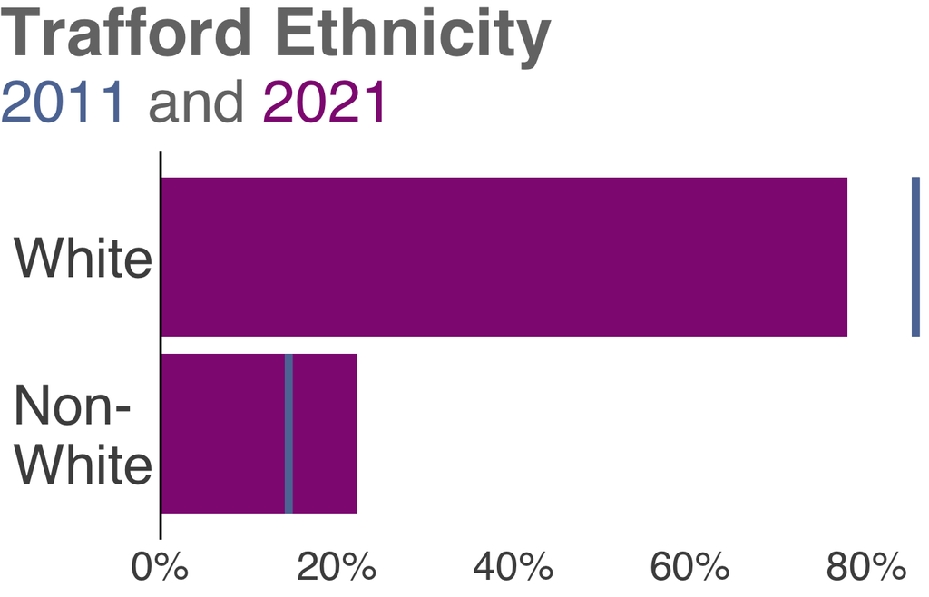

|  | 2011 | 2021 | Change |
| --- | --- | --- | --- |
| White | 85.5% | 77.8% | -7.7% |
| Non- White | 14.5% | 22.3% | 7.8% |

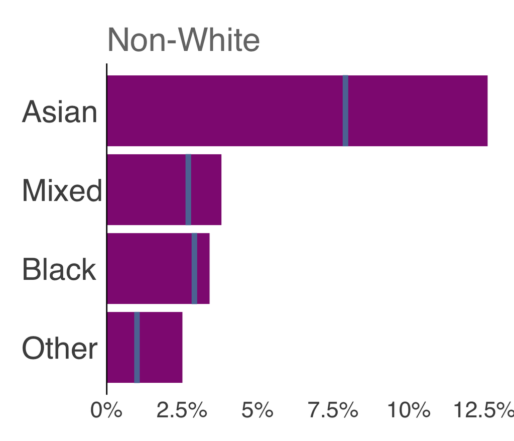

|  | 2011 | 2021 | Change |
| --- | --- | --- | --- |
| Asian | 7.9% | 12.6% | 4.7% |
| Mixed | 2.7% | 3.8% | 1.1% |
| Black | 2.9% | 3.4% | 0.5% |
| Other | 1% | 2.5% | 1.5% |

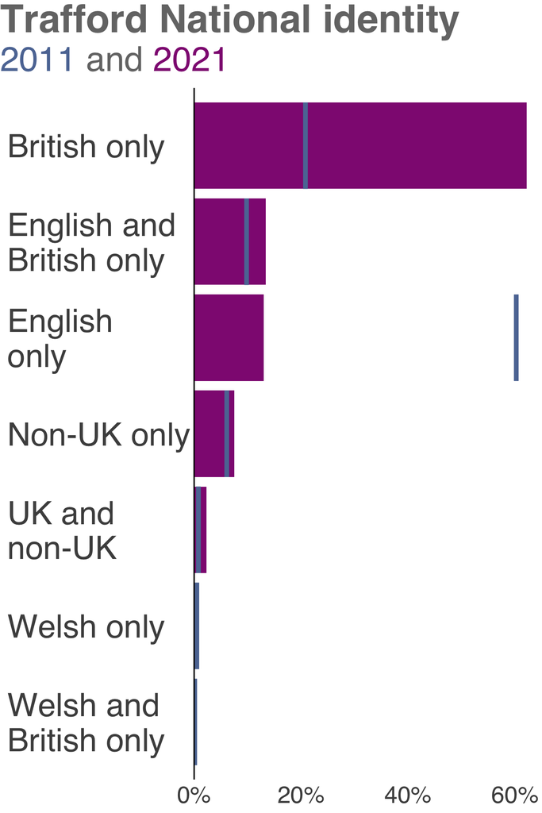

|  | 2011 | 2021 | Change |
| --- | --- | --- | --- |
| B* only | 20.8% | 62.1% | 41.3% |
| E* and B* only | 9.8% | 13.4% | 3.6% |
| E* only | 60.2% | 13% | -47.2% |
| Non-UK only | 6.1% | 7.5% | 1.4% |
| UK and non-UK | 0.8% | 2.3% | 1.5% |
| W* only | 0.5% | 0.3% | -0.2% |
| W* and B* only | 0.1% | 0.2% | 0.1% |

B* = British, E* = English and W* = Welsh

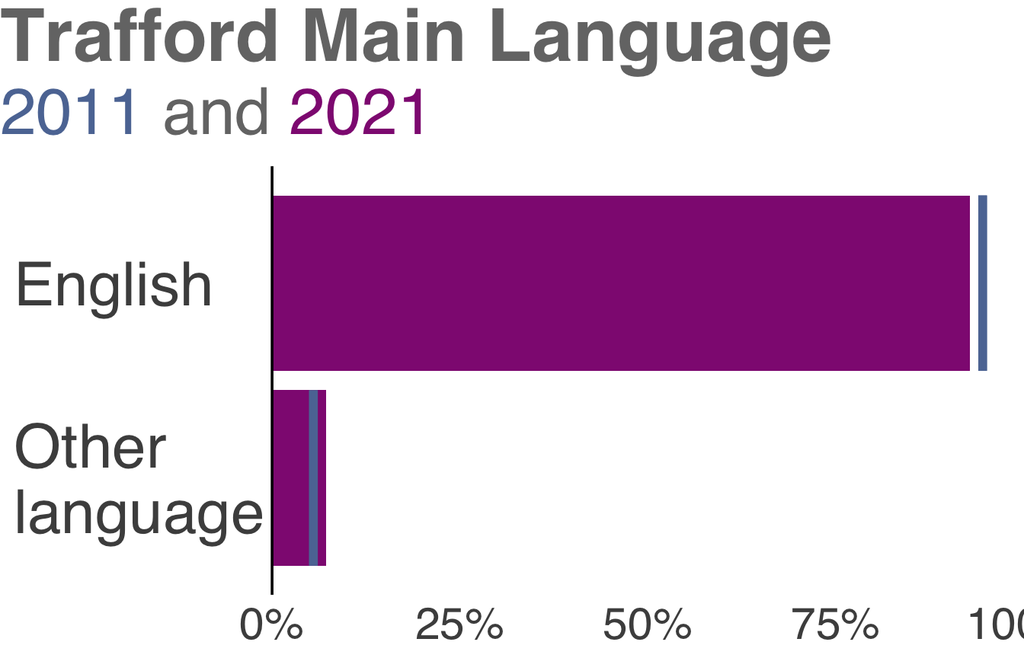

|  | 2011 | 2021 | Change |
| --- | --- | --- | --- |
| English | 94.5% | 92.8% | -1.7% |
| Other language | 5.5% | 7.2% | 1.7% |

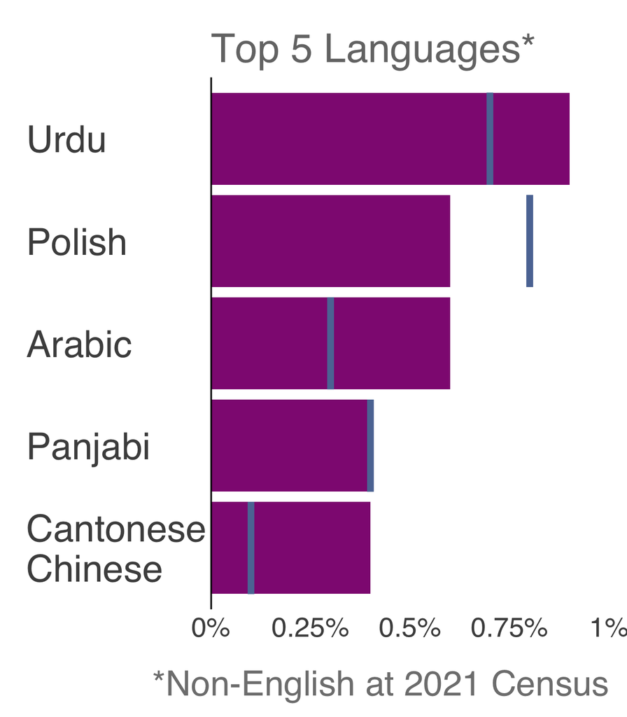

|  | 2011 | 2021 | Change |
| --- | --- | --- | --- |
| Urdu | 0.7% | 0.9% | 0.2% |
| Polish | 0.8% | 0.6% | -0.2% |
| Arabic | 0.3% | 0.6% | 0.3% |
| Panjabi | 0.4% | 0.4% | 0% |
| Cantonese Chinese | 0.1% | 0.4% | 0.3% |

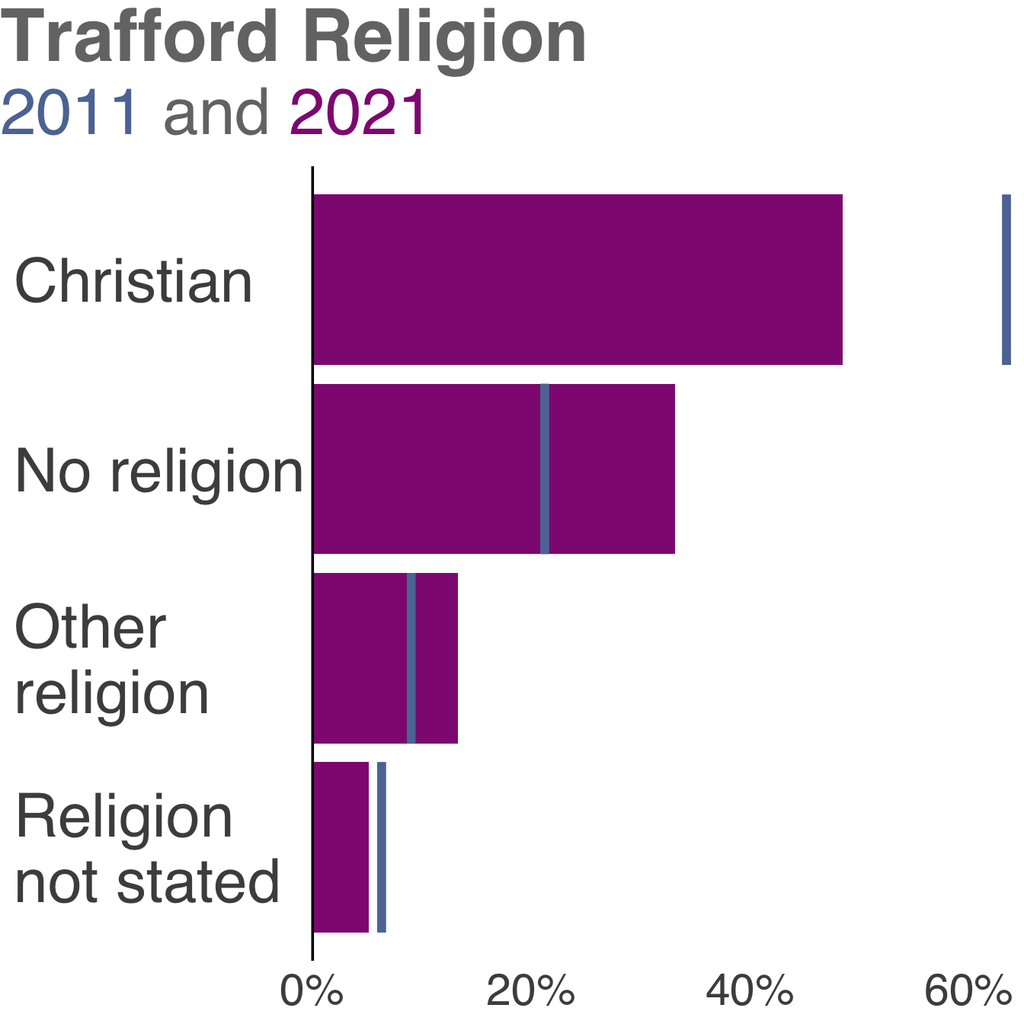

|  | 2011 | 2021 | Change |
| --- | --- | --- | --- |
| Christian | 63.4% | 48.4% | -15% |
| No religion | 21.2% | 33.1% | 11.9% |
| Other religion | 9% | 13.3% | 4.3% |
| Religion not stated | 6.3% | 5.1% | -1.2% |

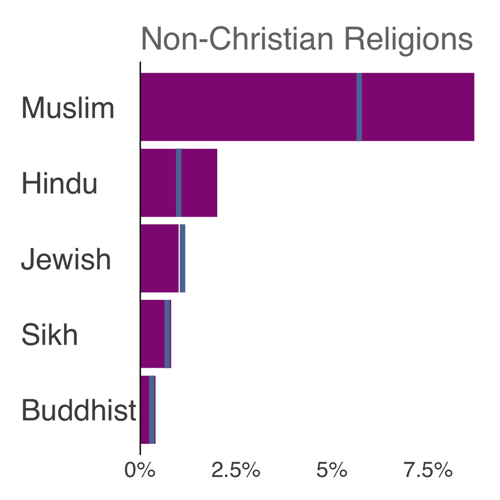

|  | 2011 | 2021 | Change |
| --- | --- | --- | --- |
| Muslim | 5.7% | 8.7% | 3% |
| Hindu | 1% | 2% | 1% |
| Jewish | 1.1% | 1% | -0.1% |
| Sikh | 0.7% | 0.8% | 0.1% |
| Buddhist | 0.3% | 0.4% | 0.1% |